# Introducción a métodos gráficos

Paul Esker

## Conjunto de datos

En este ejericio introductorio vamos a utilizar el mismo conjunto de datos de *trigo*. Simplemente lo que vamos a hacer son algunos tipos de gráficas diferentes depende del número de observaciones. En cada paso la idea sería aplicar los conceptos que vienen del paquete de *ggplot2*.

```r
library(tidyverse)
library(purrr)
library(dplyr)
library(magrittr)
library(Hmisc)
# La codificación a continuación viene del documento, "Ejemplo introductorio"

Tratamiento <- factor(rep(1:27, each=3))
Fungicida <- factor(rep(1:9, each=9))
Dosis <- factor(rep(1:3, each=3, times=9))
Rep <-factor(rep(1:3, times=27))
Incidencia <- c(3,4,5,0,2,3,0,5,5,5,4,3,3,2,4,5,4,5,5,7,5,0,7,5,6,5,4,0,5,5,0,4,0,0,3,2,0,5,5,0,4,5,5,4,5,0,2,5,5,5,2,5,5,4,3,5,4,5,5,5,5,5,0,5,4,5,3,5,0,0,5,4,0,5,2,3,5,5,0,4,2)
Rendimiento <- c(4548,5326,4715,5129,5513,4642,5359,5133,4792,5265,5008,5304,5514,5531,5183,5412,5199,5491,5727,5437,5206,5452,5258,5280,5375,4825,5558,5535,5557,5692,5758,5285,5450,5185,5659,5759,5303,5049,5099,5658,5374,5335,5451,5581,5400,5439,5068,5085,5800,4904,5206,5947,4868,5126,5511,5266,5368,5662,5273,5274,5102,5450,5426,5726,5278,5581,5100,5335,5744,5396,5018,5626,6162,5548,5371,5232,5349,5264,5771,5408,5595)

trigo<-data.frame(Tratamiento,Fungicida,Dosis,Rep,Incidencia,Rendimiento)
```

## Diagrama de caja y bigotes

En el primer ejemplo vamos a hacer una gráfica que se llama *diagrama de caja y bigotes* (box-and-whisker plot en inglés). Este diagrama conforme de los siguientes componentes: (1) valor mínimo, (2) valor máximo, (3) los cuartiles 25%, 50%, 75%, y (4) el cálculo y la identificación de datos atípicos con based en el uso del rango intercuartílico.

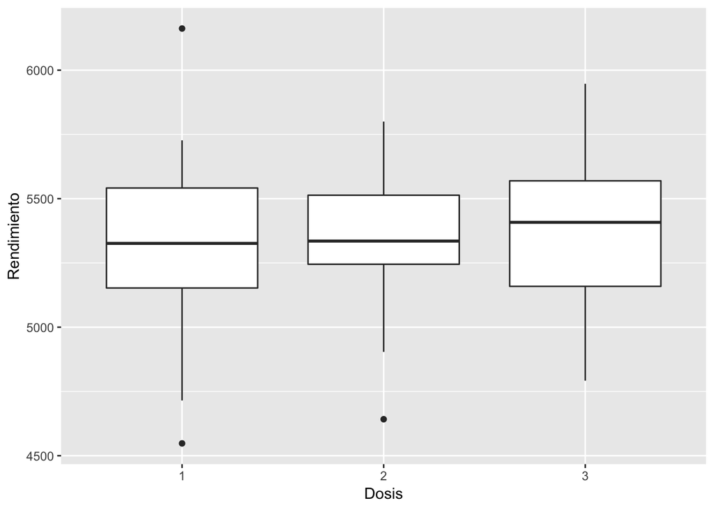

```r
# Ejemplo 1.
# En el primer ejemplo lo que vamos a hacer son una seríe de gráficas simplemente para visualizar mejor el proceso involucrado en hacer gráficas de alta calidad con *ggplot2*

ejemplo1 <- ggplot(data=trigo, aes(x=Dosis, y=Rendimiento))

ejemplo1 + geom_boxplot()
```

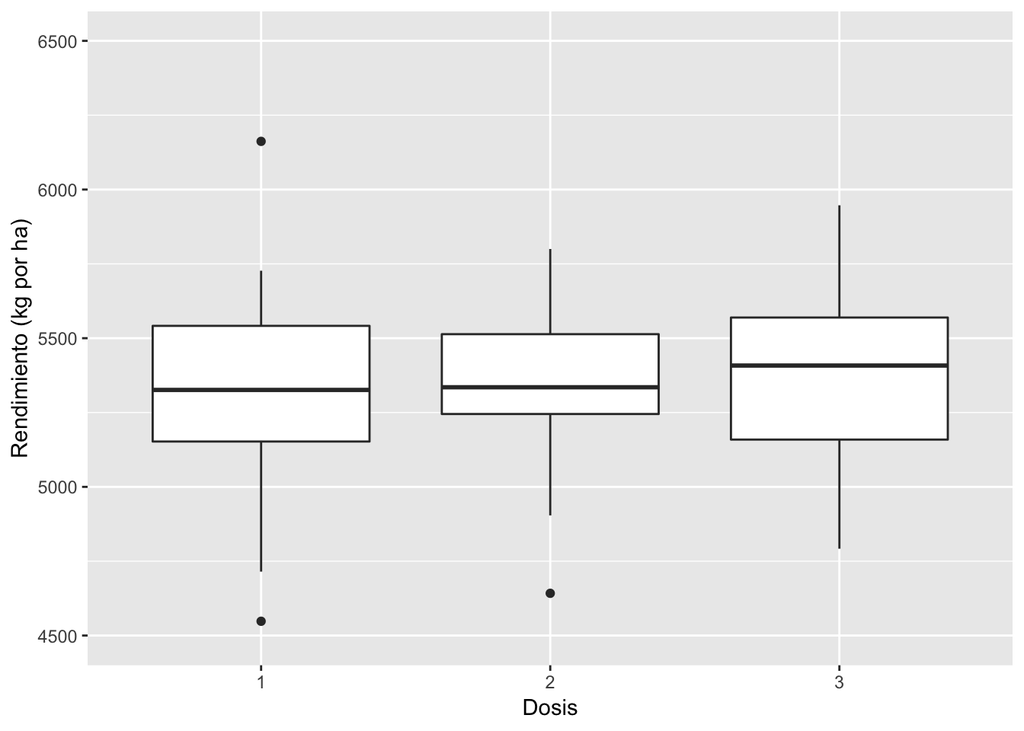

```r
ejemplo1 + geom_boxplot() + ylab("Rendimiento (kg por ha)") +
scale_y_continuous(limits=c(4500, 6500))
```

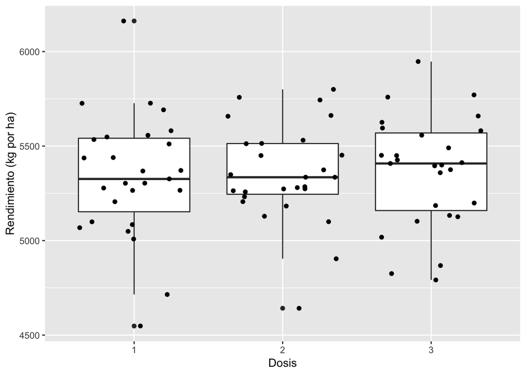

```r
ejemplo1 + geom_boxplot() + ylab("Rendimiento (kg por ha)") + geom_jitter()
```

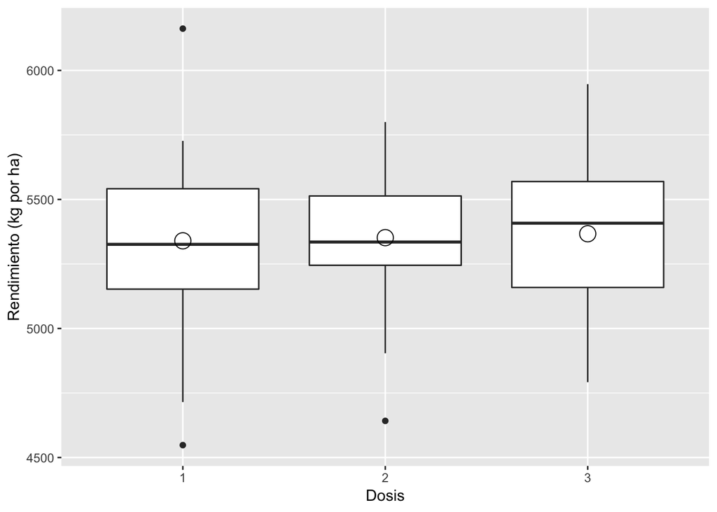

```r
ejemplo1 + geom_boxplot() +
  ylab("Rendimiento (kg por ha)") +
  stat_summary(fun.y=mean, geom="point", shape=21, size=5)
```

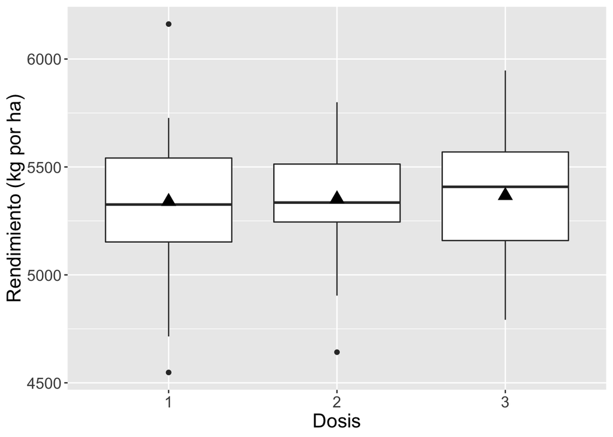

```r
ejemplo1 + geom_boxplot() +
  ylab("Rendimiento (kg por ha)") +
  stat_summary(fun.y=mean, geom="point", shape=17, size=4) +
  theme(text=element_text(size=16))
```

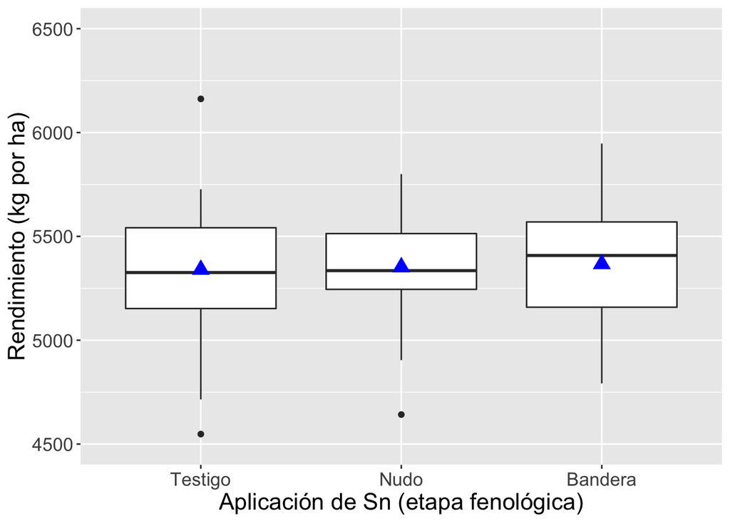

```r
ejemplo1 + geom_boxplot() + ylab("Rendimiento (kg por ha)") +
  xlab("Aplicación de Sn (etapa fenológica)") +
  stat_summary(fun.y=mean, geom="point", shape=17, size=4, colour="blue") +
  theme(text=element_text(size=16))+
  scale_x_discrete(breaks=c("1","2","3"),labels=c("Testigo", "Nudo", "Bandera")) +
  scale_y_continuous(limits=c(4500, 6500))
```

## Ejemplo de diagrama de barras

En este ejemplo lo que vamos a ilustrar es la creación de un diagrama de barras en donde se incluyen barras de error. Para este ejemplo vamos a aplicar primero lo que hemos hecho en el ejemplo introductorio para resumir los datos por el factor de *dosis*. De ahí la gráfica se hace mediante las herramientas disponibles con el paquete *ggplot2*.

```r
# Ejemplo 2.
# En este primer paso se agregó dos líneas adicionales para poder calcular los errores estándares. También en esta situación vamos a guardar el conjunto nuevo de datos a la memoría de R.

dosis <- trigo %>% group_by(Dosis)

dosis_resumen <- dosis %>% summarise(
  Inc_media = mean(Incidencia),
  Inc_sd = sd(Incidencia),
  Inc_se = sd(Incidencia)/sqrt(n()),
  Inc_cv = sd(Incidencia)/mean(Incidencia)*100,
  Rend_media = mean(Rendimiento),
  Rend_sd = sd(Rendimiento),
  Rend_se = sd(Rendimiento)/sqrt(n()),
  Rend_cv = Rend_sd/Rend_media*100
)

dosis_resumen
```

| Dosis | Inc_media | Inc_sd | Inc_se | Inc_cv | Rend_media | Rend_sd | Rend_se | Rend_cv |
| --- | --- | --- | --- | --- | --- | --- | --- | --- |
| 1 | 3.740741 | 1.913366 | 0.3682274 | 51.14938 | 5339.778 | 327.0293 | 62.93682 | 6.124400 |
| 2 | 3.222222 | 2.100061 | 0.4041569 | 65.17431 | 5352.037 | 258.3016 | 49.71017 | 4.826230 |
| 3 | 3.592593 | 1.966239 | 0.3784029 | 54.73037 | 5367.111 | 292.0783 | 56.21049 | 5.442002 |

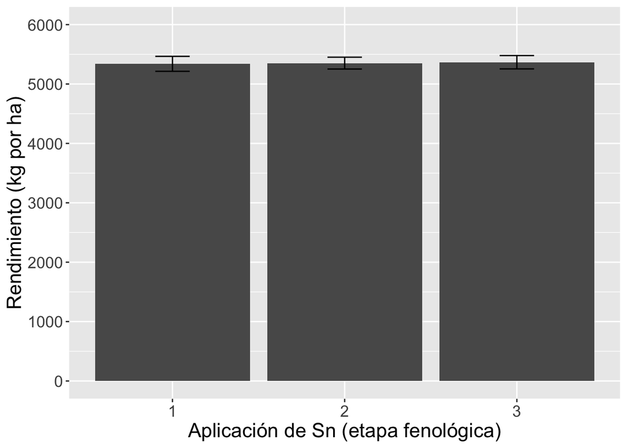

```r
# Ahora vamos a hacer la gráfica de tal manera: (1) hacer las barras mediante la opción geom_col() utilizando la columna Rend_media, (2) agregar las barras de error de tipo +/- 2 se

Rend_barras <- ggplot(dosis_resumen, aes(Dosis, Rend_media)) +
  geom_col() +
  geom_errorbar(aes(ymin=Rend_media - 2*Rend_se, ymax=Rend_media + 2*Rend_se), width=0.2) +
  theme(text=element_text(size=16)) +
  ylab("Rendimiento (kg por ha)") +
  xlab("Aplicación de Sn (etapa fenológica)") +
  scale_y_continuous(limits=c(0, 6000), breaks=c(0,1000,2000,3000,4000,5000,6000))

Rend_barras
```

## Ejemplo de gráfica de dispersión

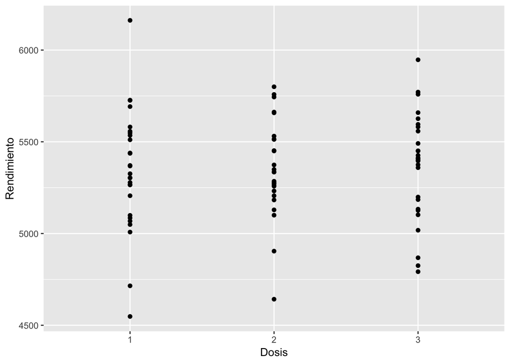

```r
# Ejemplo 3.
# Diagrama de dispersión con información sobre la media y las barras de error

ejemplo3<-ggplot(data=trigo, aes(x=Dosis, y=Rendimiento))

ejemplo3 + geom_point()
```

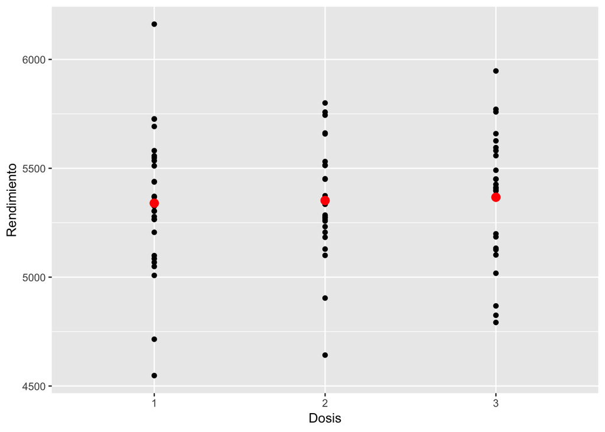

```r
ejemplo3 +  geom_point() +
  stat_summary(fun.y=mean, geom="point", colour="red", size=3)
```

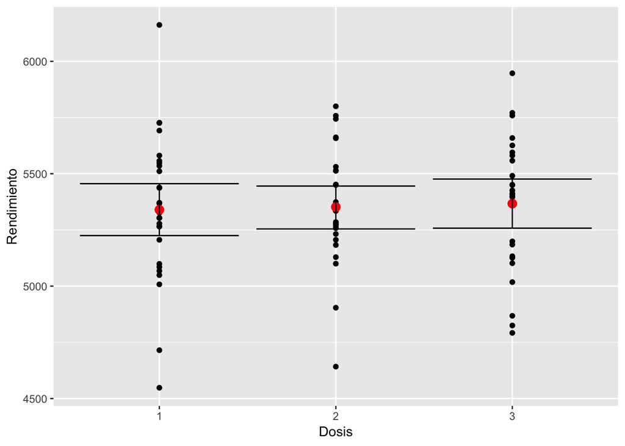

```r
ejemplo3 +
  geom_point() +
  stat_summary(fun.y=mean, geom="point", colour="red", size=3) +
  stat_summary(fun.data=mean_cl_boot, geom="errorbar")
```

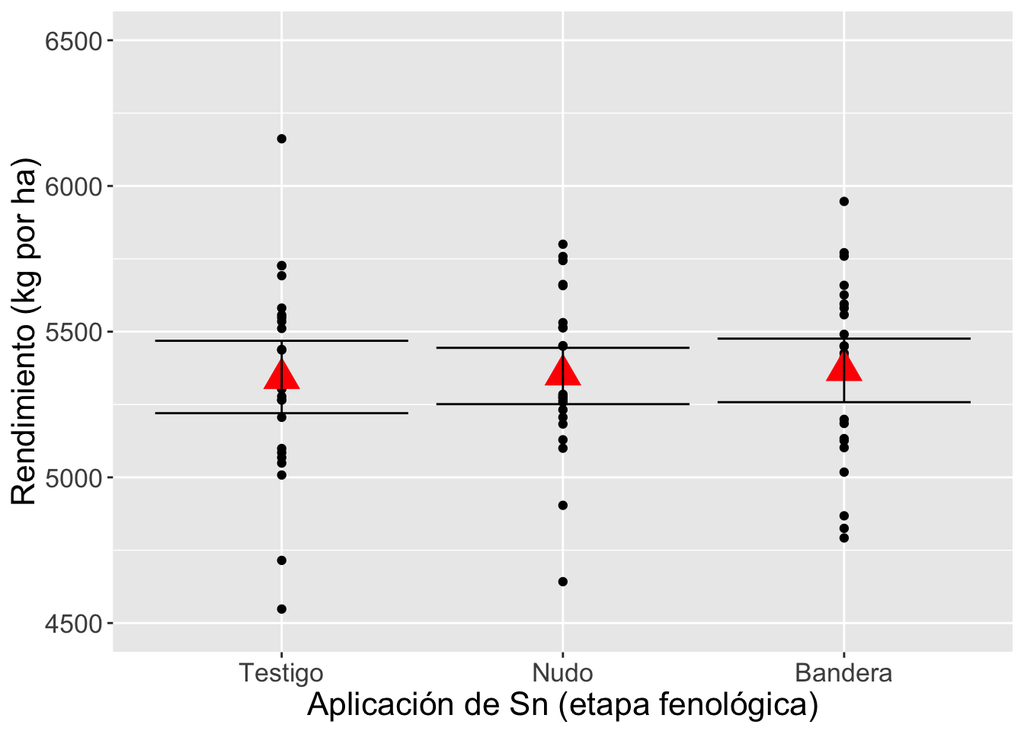

```r
ejemplo3 +
  geom_point() +
  ylab("Rendimiento (kg por ha)") +
  xlab("Aplicación de Sn (etapa fenológica)") +
  stat_summary(fun.y=mean, geom="point", colour="red",size=6, shape=17) +
  stat_summary(fun.data=mean_cl_boot, geom="errorbar") +
  theme(text=element_text(size=16)) +
  scale_x_discrete(breaks=c("1","2","3"),labels=c("Testigo", "Nudo", "Bandera")) +
  scale_y_continuous(limits=c(4500, 6500), breaks=c(4500,5000,5500,6000,6500))
```

## Resumen

En este ejercicio se presentó algunos ejemplos de tipos diferentes de gráficos que pueden ser considerados para explorar los datos obtenidos en una investigación. Durante las secciones que viene vamos a extender este concepto mediante ejemplos más enfocados en modelado. No siempre vamos a utilizar los métodos dados en *ggplot2* debido a que mucho depende en lo que es el estudio y la necesidad de crear un gráfico más avanzado.